# Red & White Wine Analysis

# Univariate Plots Section

> **Tip**: In this section, you should perform some preliminary exploration of your dataset. Run some summaries of the data and create univariate plots to understand the structure of the individual variables in your dataset. Don’t forget to add a comment after each plot or closely-related group of plots! There should be multiple code chunks and text sections; the first one below is just to help you get started.

```r
head(subset(wine_data, wine_data['type'] == 'white'))
```

|  | X | fixed.acidity | volatile.acidity | citric.acid | residual.sugar | chlorides | free.sulfur.dioxide | total.sulfur.dioxide | density | pH | sulphates | alcohol | quality | type |
| --- | --- | --- | --- | --- | --- | --- | --- | --- | --- | --- | --- | --- | --- | --- |
| 1600 | 1 | 7.0 | 0.27 | 0.36 | 20.7 | 0.045 | 45 | 170 | 1.0010 | 3.00 | 0.45 | 8.8 | 6 | white |
| 1601 | 2 | 6.3 | 0.30 | 0.34 | 1.6 | 0.049 | 14 | 132 | 0.9940 | 3.30 | 0.49 | 9.5 | 6 | white |
| 1602 | 3 | 8.1 | 0.28 | 0.40 | 6.9 | 0.050 | 30 | 97 | 0.9951 | 3.26 | 0.44 | 10.1 | 6 | white |
| 1603 | 4 | 7.2 | 0.23 | 0.32 | 8.5 | 0.058 | 47 | 186 | 0.9956 | 3.19 | 0.40 | 9.9 | 6 | white |
| 1604 | 5 | 7.2 | 0.23 | 0.32 | 8.5 | 0.058 | 47 | 186 | 0.9956 | 3.19 | 0.40 | 9.9 | 6 | white |
| 1605 | 6 | 8.1 | 0.28 | 0.40 | 6.9 | 0.050 | 30 | 97 | 0.9951 | 3.26 | 0.44 | 10.1 | 6 | white |

```r
dim(subset(wine_data, wine_data['type'] == 'white'))
```

```
[1] 4898   14
```

```r
summary(subset(wine_data, wine_data['type'] == 'white'))
```

```
       X        fixed.acidity    volatile.acidity  citric.acid     residual.sugar
 Min.   :   1   Min.   : 3.800   Min.   :0.0800   Min.   :0.0000   Min.   : 0.600
 1st Qu.:1225   1st Qu.: 6.300   1st Qu.:0.2100   1st Qu.:0.2700   1st Qu.: 1.700
 Median :2450   Median : 6.800   Median :0.2600   Median :0.3200   Median : 5.200
 Mean   :2450   Mean   : 6.855   Mean   :0.2782   Mean   :0.3342   Mean   : 6.391
 3rd Qu.:3674   3rd Qu.: 7.300   3rd Qu.:0.3200   3rd Qu.:0.3900   3rd Qu.: 9.900
 Max.   :4898   Max.   :14.200   Max.   :1.1000   Max.   :1.6600   Max.   :65.800
   chlorides       free.sulfur.dioxide total.sulfur.dioxide    density             pH
 Min.   :0.00900   Min.   :  2.00      Min.   :  9.0        Min.   :0.9871   Min.   :2.720
 1st Qu.:0.03600   1st Qu.: 23.00      1st Qu.:108.0        1st Qu.:0.9917   1st Qu.:3.090
 Median :0.04300   Median : 34.00      Median :134.0        Median :0.9937   Median :3.180
 Mean   :0.04577   Mean   : 35.31      Mean   :138.4        Mean   :0.9940   Mean   :3.188
 3rd Qu.:0.05000   3rd Qu.: 46.00      3rd Qu.:167.0        3rd Qu.:0.9961   3rd Qu.:3.280
 Max.   :0.34600   Max.   :289.00      Max.   :440.0        Max.   :1.0390   Max.   :3.820
   sulphates         alcohol         quality          type
 Min.   :0.2200   Min.   : 8.00   Min.   :3.000   Length:4898
 1st Qu.:0.4100   1st Qu.: 9.50   1st Qu.:5.000   Class :character
 Median :0.4700   Median :10.40   Median :6.000   Mode  :character
 Mean   :0.4898   Mean   :10.51   Mean   :5.878
 3rd Qu.:0.5500   3rd Qu.:11.40   3rd Qu.:6.000
 Max.   :1.0800   Max.   :14.20   Max.   :9.000
```

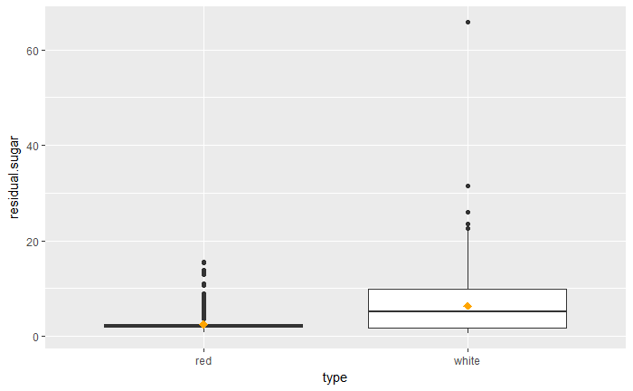

```r
ggplot(wine_data, aes(type, residual.sugar))+
  geom_boxplot()+
  stat_summary(fun.y=mean, color="orange", geom="point",
               shape=18, size=3)
```

We know that number of observations for red and white are different in out dataset, but still we can see that for both colors it’s normal distribution with almost the same picks at 5 and 6 quality point.

```r
summary(wine_data$quality)
```

```
   Min. 1st Qu.  Median    Mean 3rd Qu.    Max.
  3.000   5.000   6.000   5.818   6.000   9.000
```

```r
table(wine_data$quality)
```

```
   3    4    5    6    7    8    9
  30  216 2138 2836 1079  193    5
```

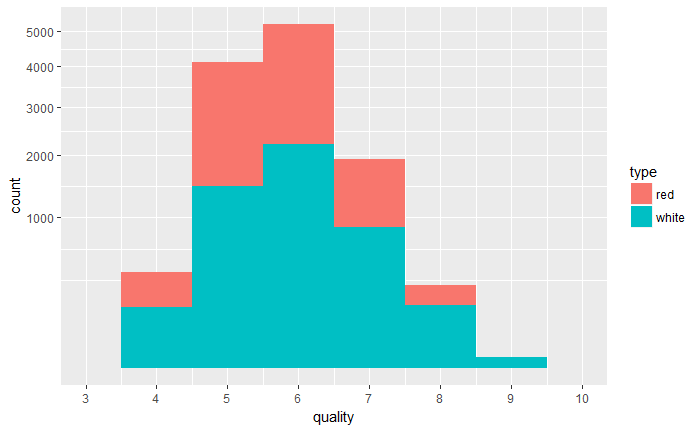

```r
qplot(quality, data = wine_data, fill = type, binwidth = 1)+
    scale_x_continuous(breaks = seq(3,10,1), lim = c(3,10)) +
    scale_y_sqrt()
```

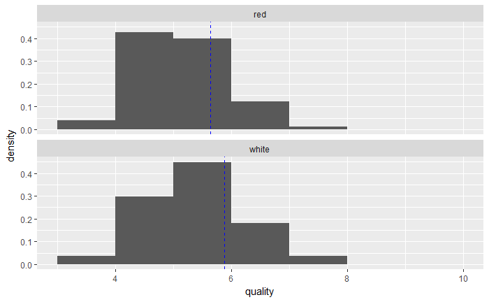

```r
ggplot(wine_data, aes(quality))+
  geom_histogram(aes(y=..density..), breaks = seq(3,10,1))+
  facet_wrap(~type, ncol = 1 ) +
  geom_vline(data=filter(wine_data,type == "red"),aes(xintercept = mean(quality),group = type),col='blue',size=0.4, linetype = "dashed")+
    geom_vline(data=filter(wine_data, type == "white"),aes(xintercept = mean(quality),group = type),col='blue',size=0.4, linetype = "dashed")
```

Alcohol level distribution looks skewed. Again, red wine sample is smaller but it gives the same pattern of alcohol level distribution as while wines. Most frequently wines have 9.5%, mean is 10.49% of alcohol.

```r
summary(wine_data$alcohol)
```

```
   Min. 1st Qu.  Median    Mean 3rd Qu.    Max.
   8.00    9.50   10.30   10.49   11.30   14.90
```

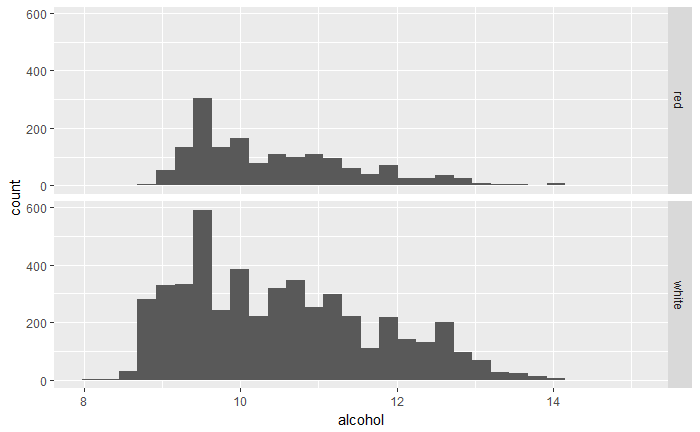

```r
ggplot(wine_data, aes(alcohol)) +
  geom_histogram() +
  facet_grid(type~.)
```

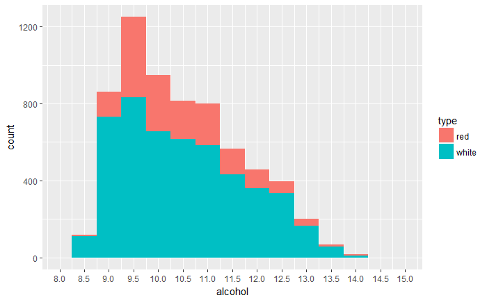

```r
qplot(alcohol, data = wine_data, fill = type, binwidth = 0.5) +
    scale_x_continuous(breaks = seq(8,15,0.5), lim = c(8,15))
```

```r
summary(wine_data$density)
```

```
   Min. 1st Qu.  Median    Mean 3rd Qu.    Max.
 0.9871  0.9923  0.9949  0.9947  0.9970  1.0390
```

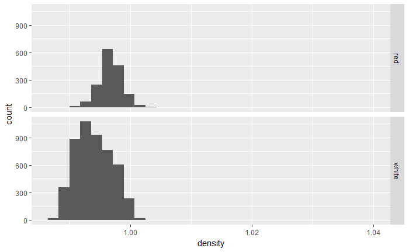

```r
ggplot(wine_data, aes(density)) +
  geom_histogram() +
  facet_grid(type~.)
```

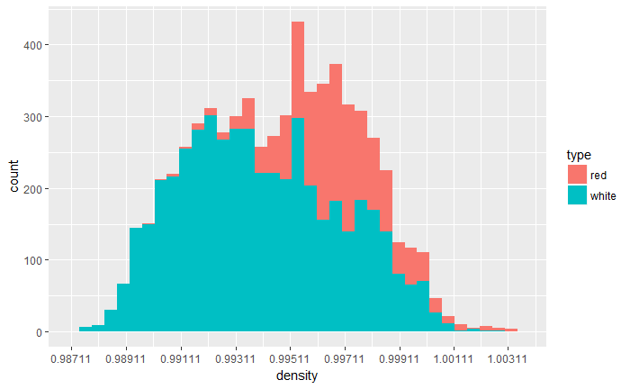

```r
qplot(density, data = wine_data, fill = type, binwidth = 0.0002) +
    scale_x_log10(lim = c(min(wine_data$density), 1.00370),
                  breaks = seq(min(wine_data$density), 1.00370, 0.002))
```

```r
summary(wine_data$volatile.acidity)
```

```
   Min. 1st Qu.  Median    Mean 3rd Qu.    Max.
 0.0800  0.2300  0.2900  0.3397  0.4000  1.5800
```

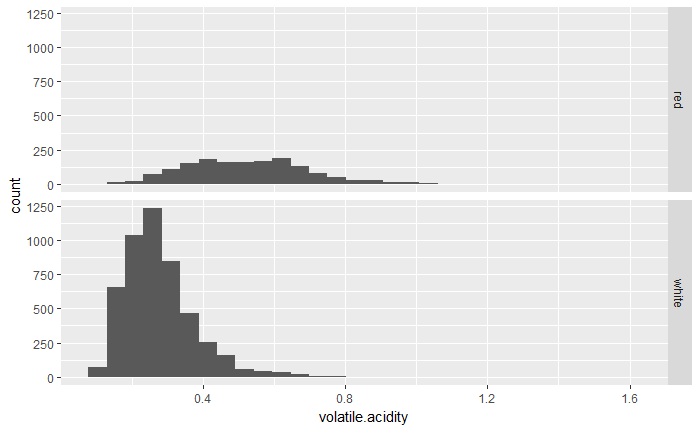

```r
ggplot(wine_data, aes(volatile.acidity)) +
  geom_histogram() +
  facet_grid(type~.)
```

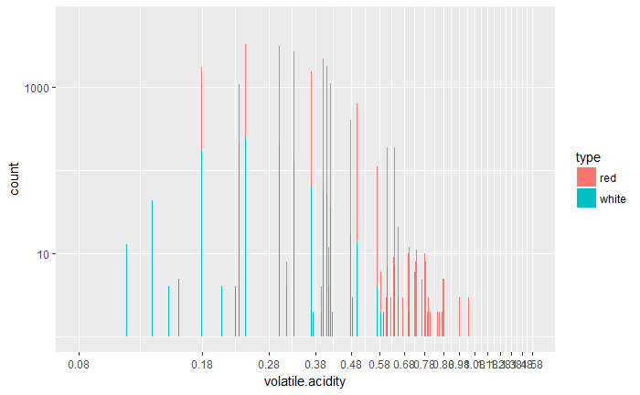

```r
qplot(volatile.acidity, data = wine_data, fill = type, binwidth = 0.001) +
    scale_x_log10(breaks = seq(min(wine_data$volatile.acidity),
                               max(wine_data$volatile.acidity), 0.1)) +
  scale_y_log10()
```

```r
summary(wine_data $chlorides)
```

```
   Min. 1st Qu.  Median    Mean 3rd Qu.    Max.
0.00900 0.03800 0.04700 0.05603 0.06500 0.61100
```

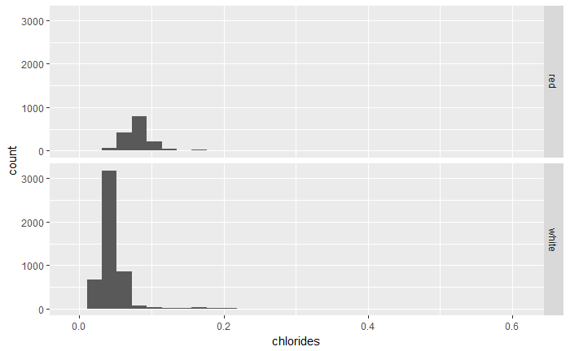

```r
ggplot(wine_data, aes(chlorides)) +
  geom_histogram() +
  facet_grid(type~.)
```

```r
qplot(chlorides, data = wine_data, fill = type, binwidth = 0.01) +
    scale_x_log10(breaks = seq(min(wine_data$chlorides), quartile(wine_data$chlorides), 0.9))
```

[output not shown]

> **Tip**: Make sure that you leave a blank line between the start / end of each code block and the end / start of your Markdown text so that it is formatted nicely in the knitted text. Note as well that text on consecutive lines is treated as a single space. Make sure you have a blank line between your paragraphs so that they too are formatted for easy readability.

# Univariate Analysis

> **Tip**: Now that you’ve completed your univariate explorations, it’s time to reflect on and summarize what you’ve found. Use the questions below to help you gather your observations and add your own if you have other thoughts!

### What is the structure of your dataset?

### What is/are the main feature(s) of interest in your dataset?

### What other features in the dataset do you think will help support your investigation into your feature(s) of interest?

### Did you create any new variables from existing variables in the dataset?

### Of the features you investigated, were there any unusual distributions? Did you perform any operations on the data to tidy, adjust, or change the form of the data? If so, why did you do this?

# Bivariate Plots Section

> **Tip**: Based on what you saw in the univariate plots, what relationships between variables might be interesting to look at in this section? Don’t limit yourself to relationships between a main output feature and one of the supporting variables. Try to look at relationships between supporting variables as well.

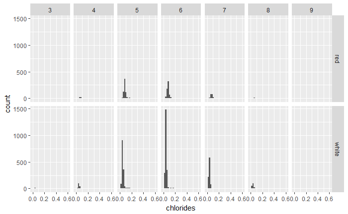

```r
ggplot(wine_data, aes(chlorides)) +
  geom_histogram() +
  facet_grid(type~quality)
```

alcohol vs. density fixed.acidity vs. density residual.sugar vs total.sulfur.dioxide residual.sugar vs. density residual.sugar vs. alcohol chlorides vs. density chlorides vs. sulphates quality vs. alcohol

Compare objective parameters of wines

```r
# use function for plotting with ggplot for simplicity of code
f <- function(wine_data, x, y, z, opts=NULL) {
  ggplot(wine_data, aes_string(x = x, y = y, color = z)) +
   geom_point(alpha = 1/5, position = position_jitter(h = 0), size = 2) +
   geom_smooth(method = 'lm')
}

# density vs. alcohol plot
p <- f(wine_data, "density", "alcohol", "type")
p + coord_cartesian(xlim=c(min(wine_data$density),1.005), ylim=c(8,15))

# density vs. fixed.acidity plot
p <- f(wine_data, "density", "fixed.acidity", "type")
p + coord_cartesian(xlim=c(min(wine_data$density),1.005))

# residual.sugar vs. total.sulfur.dioxide
p <- f(wine_data, "residual.sugar", "total.sulfur.dioxide", "type")
p + scale_x_log10() +
    coord_cartesian(xlim=c(min(wine_data$residual.sugar),30),
                    ylim=c(min(wine_data$total.sulfur.dioxide), 350))

# residual.sugar vs. density
p <- f(wine_data, "residual.sugar", "density", "type")
p + coord_cartesian(xlim=c(min(wine_data$residual.sugar),25),
                    ylim=c(min(wine_data$density), 1.005))

# residual.sugar vs. alcohol
p <- f(wine_data, "residual.sugar", "alcohol", "type")
p + coord_cartesian(xlim=c(min(wine_data$residual.sugar),25),
                    ylim=c(min(wine_data$alcohol), 15))

# chlorides vs. density
p <- f(wine_data, "chlorides", "density", "type")
p + scale_x_log10() +
    coord_cartesian(ylim=c(min(wine_data$density), 1.005))

# chlorides vs. sulphates
p <- f(wine_data, "chlorides", "sulphates", "type")
p + scale_x_log10() +
    coord_cartesian(ylim=c(min(wine_data$sulphates), 1))
```

[output not shown]

```r
                                              RED      |     WHITE
* alcohol vs. density                    :    strong c.  :   strong c.
* fixed.acidity vs. density              :    strong c.  :     no c.
* residual.sugar vs total.sulfur.dioxide :     weak      :    weak c.
* residual.sugar vs. density             :    strong c.  :   strong c.
* residual.sugar vs. alcohol             :     no c.     :   strong c.
* chlorides vs. density                  :    strong c.  :   strong c.
* chlorides vs. sulphates                :    strong c.  :     no c.
```

Compare Quality vs. Alcohol

```r
ggplot(data = wine_data, aes(y = alcohol, x = quality)) +
   geom_point(alpha = 1/4, position = position_jitter(h = 0), size = 4) +
   geom_smooth(method = 'lm') +
   facet_wrap(~ type)
```

[output not shown]

Significantly Different Parameters for Red and White Wine

Fixed Acidity vs. Color

```r
qplot(x = type, y = fixed.acidity, data = wine_data, geom = "boxplot")
```

[output not shown]

Volatile Acidity vs. Color

```r
qplot(x = type, y = volatile.acidity, data = wine_data, geom = "boxplot")
```

[output not shown]

Residual Sugar vs. Color

```r
qplot(x = type, y = residual.sugar, data = wine_data, geom = "boxplot")
```

[output not shown]

Total Sulfur Dioxide vs. Color

```r
qplot(x = type, y = total.sulfur.dioxide, data = wine_data, geom = "boxplot")
```

[output not shown]

These are parameters which depend a lot on the color of wine.

Quality of Red and White Wines

```r
qplot(x = type, y = quality, data = wine_data, geom = "boxplot")
```

[output not shown]

Exploring Wine Parameters and Quality Chlorides and Sulphates

```r
# converting 'quality' vector into factor variable
wine_data$quality <- as.factor(wine_data$quality)

ggplot(aes(x = chlorides, y = sulphates, color = quality), data = wine_data) +
    facet_wrap(~type) +
    geom_point(size = 3, alpha = 1/4) +
    scale_color_identity(guide = 'legend') +
    ylim(min(wine_data$sulphates), quantile(wine_data$sulphates, 0.95)) +
    xlim(min(wine_data$chlorides), quantile(wine_data$chlorides, 0.95))
```

[output not shown]

Fixed Acidity and Volatile Acidity

```r
ggplot(aes(x = fixed.acidity,
           y = volatile.acidity,
           color = quality),
       data = wine_data) +
    facet_wrap(~type) +
    geom_point(size = 3, alpha = 1/4) +
    scale_color_identity(guide = 'legend') +
    ylim(min(wine_data$volatile.acidity),
         quantile(wine_data$volatile.acidity, 0.99)) +
    xlim(min(wine_data$fixed.acidity),
         quantile(wine_data$fixed.acidity, 0.99))
```

[output not shown]

Free Sulfur Dioxide and Total Sulfur Dioxide

```r
ggplot(aes(x = free.sulfur.dioxide,
           y = total.sulfur.dioxide,
           color = quality),
       data = wine_data) +
    facet_wrap(~type) +
    geom_point(size = 3, alpha = 1/4) +
    scale_color_identity(guide = 'legend') +
    ylim(min(wine_data$total.sulfur.dioxide),
         quantile(wine_data$total.sulfur.dioxide, 0.95)) +
    xlim(min(wine_data$free.sulfur.dioxide),
         quantile(wine_data$free.sulfur.dioxide, 0.95))
```

[output not shown]

PH and Alcohol

```r
ggplot(aes(x = pH, y = alcohol, color = quality), data = wine_data) +
    facet_wrap(~type) +
    geom_point(size = 3, alpha = 1/4) +
    scale_color_identity(guide = 'legend') +
    ylim(min(wine_data$alcohol), quantile(wine_data$alcohol, 0.95)) +
    xlim(min(wine_data$pH), quantile(wine_data$pH, 0.95))
```

[output not shown]

Citric Acid and Alcohol

```r
ggplot(aes(x = citric.acid, y = alcohol, color = quality),
       data = wine_data) +
    facet_wrap(~type) +
    geom_point(size = 3, alpha = 1/4) +
    scale_color_identity(guide = 'legend') +
    ylim(min(wine_data$alcohol), quantile(wine_data$alcohol, 0.95)) +
    xlim(min(wine_data$citric.acid), quantile(wine_data$citric.acid, 0.95))
```

[output not shown]

# Bivariate Analysis

> **Tip**: As before, summarize what you found in your bivariate explorations here. Use the questions below to guide your discussion.

### Talk about some of the relationships you observed in this part of the investigation. How did the feature(s) of interest vary with other features in the dataset?

### Did you observe any interesting relationships between the other features (not the main feature(s) of interest)?

### What was the strongest relationship you found?

# Multivariate Plots Section

> **Tip**: Now it’s time to put everything together. Based on what you found in the bivariate plots section, create a few multivariate plots to investigate more complex interactions between variables. Make sure that the plots that you create here are justified by the plots you explored in the previous section. If you plan on creating any mathematical models, this is the section where you will do that.

# Multivariate Analysis

### Talk about some of the relationships you observed in this part of the investigation. Were there features that strengthened each other in terms of looking at your feature(s) of interest?

### Were there any interesting or surprising interactions between features?

### OPTIONAL: Did you create any models with your dataset? Discuss the strengths and limitations of your model.

# Final Plots and Summary

> **Tip**: You’ve done a lot of exploration and have built up an understanding of the structure of and relationships between the variables in your dataset. Here, you will select three plots from all of your previous exploration to present here as a summary of some of your most interesting findings. Make sure that you have refined your selected plots for good titling, axis labels (with units), and good aesthetic choices (e.g. color, transparency). After each plot, make sure you justify why you chose each plot by describing what it shows.

### Plot Two: Correlation Between Objective Parameters

```r
ggplot(data = wine_data,
       aes(x = density, y = alcohol, color = factor(quality))) +
   geom_point(alpha = 1/2, position = position_jitter(h = 0), size = 2) +
   coord_cartesian(xlim=c(min(wine_data$density),1.005), ylim=c(8,15)) +
   scale_color_brewer(type='qual') +
   xlab('Density') +
   ylab('Alcohol') +
   ggtitle('Density vs. Alcohol correlation by Quality')
```

[output not shown]

```r
ggplot(data = wine_data,
       aes(x = density, y = alcohol) )+
   facet_wrap( ~ quality) +
   geom_boxplot() +
   xlab('Density') +
   ylab('Alcohol') +
   ggtitle('Density vs. Alcohol correlation by Quality')
```

[output not shown]

# Reflection

> **Tip**: Here’s the final step! Reflect on the exploration you performed and the insights you found. What were some of the struggles that you went through? What went well? What was surprising? Make sure you include an insight into future work that could be done with the dataset.

> **Tip**: Don’t forget to remove this, and the other **Tip** sections before saving your final work and knitting the final report!

Analyzing the data we can come up the following conclusion:

According to my investigation I may conclude that experts’ decisions on wine quality levels are based on their personal testes or could depend on other variables like year of production, grape types, wine brand etc. as only one variable (alcohol level) has correlation with quality of wine.

For future exploration of this data I would pick one category of wine (for example, quality level 3-4, 5-7, 8-9) to look at the patterns which can appear in each of these three buckets. I also would normalize data because we have more white wine than red wine.